# Text Prediction with Clinical Trials Data: Mono vs. Combination Therapy

## Load The Datasets

We selected a set of 144 clinical trials for bladder cancer treatments. Each trial was hand coded according to whether it was a monotherapy or combination therapy treatment, whether the endpoint conditions were met or not, and the line of treatment. None of these features are explicitly indicated in the clinical trials database. In this notebook we will focus on building models to predict whether a trial is a monotherapy or combination therapy based on the fields that are available in the database.

To start, we will load in our hand-coded data of the clinical trials, which includes the NCD ID and our labels. We’ll also include a flag that randomly assigns each trial to a training or validation set.

```r
set.seed(1L)
bladder <- read_csv("input/ca_pool.csv") |>
  select(nct_id, official_title, endpoint_met, type_of_therapy,
         line_of_therapy, description,) |>
  mutate(bin = if_else(runif(n()) <= 0.66, "train", "valid")) |>
  filter(!duplicated(nct_id))

bladder
```

```
## # A tibble: 144 × 7
##    nct_id      official_title          endpo…¹ type_…² line_…³ descr…⁴ bin
##    <chr>       <chr>                   <chr>   <chr>   <chr>   <chr>   <chr>
##  1 NCT02302807 A Phase III, Open-Labe… Met     Monoth… 2       This i… train
##  2 NCT02042443 Randomized Phase II Tr… Not met Monoth… 2       This r… train
##  3 NCT01589094 Phase II Study of Neoa… Met     Combin… 1       The pu… train
##  4 NCT01031420 Phase II Trial of Neoa… Met     Combin… 1       Standa… valid
##  5 NCT00978250 A Multi-Histology Phas… N/A     Combin… 2       Backgr… train
##  6 NCT00661609 A Phase II, Single Arm… Not met Monoth… 3       The pu… valid
##  7 NCT00445601 A Phase III Blinded St… Met     Monoth… 1       RATION… valid
##  8 NCT00598806 A Multicenter, Randomi… Not met Monoth… 1       The pu… valid
##  9 NCT00506155 A Phase II Clinical Tr… Met     Combin… 1       The go… train
## 10 NCT00461591 A Multicenter, Randomi… Not met Monoth… 1       The pu… train
## # … with 134 more rows, and abbreviated variable names ¹endpoint_met,
## #   ²type_of_therapy, ³line_of_therapy, ⁴description
```

To build our model, we will also load several tables of data from the clinical trials database. To save time, we have taken a subset of the tables consisting of only those records connected to our trials.

```r
design_groups <- read_csv("input/design_groups.txt")
design_gint <- read_csv("input/design_group_interventions.txt")
interventions <- read_csv("input/interventions.txt")
```

We’ll discuss the content of each table as they are used in the code below.

The clinical trials database contains a table describing each of the design arms in the trial. Each contains (a subset of) a title, a description, and a group type label. For our text-based prediction model, we’ll start by collapsing all of these fields across each arm of the trial into a single text field describing the trial.

```r
dg <- design_groups |>
  mutate(description = if_else(is.na(description), "", description)) |>
  mutate(title = if_else(is.na(title), "", title)) |>
  mutate(group_type = if_else(is.na(group_type), "", group_type)) |>
  mutate(design = paste(group_type, title, description, by = " ")) |>
  group_by(nct_id) |>
  summarize(design = paste(design, collapse = " ")) |>
  select(design, nct_id)

dg
```

```
## # A tibble: 136 × 2
##    design                                                             nct_id
##    <chr>                                                              <chr>
##  1 "Active Comparator paclitaxel 3 cycles paclitaxel given for 3 cyc… NCT00…
##  2 "Experimental Carboplatin, paclitaxel, low dose paclitaxel carbop… NCT00…
##  3 "Active Comparator Arm I Patients receive paclitaxel IV over 3 ho… NCT00…
##  4 "Experimental Capecitabine + Gemcitabine Capecitabine 650 mg/m^2 … NCT00…
##  5 "Experimental bexarotene with carboplatin and paclitaxel    Exper… NCT00…
##  6 "Experimental Pelvic RT + paclitaxel + cisplatin Induction: Twice… NCT00…
##  7 "Placebo Comparator Placebo Arm Eligible subjects will complete a… NCT00…
##  8 "Placebo Comparator APC-Placebo    Active Comparator Sipuleucel-T… NCT00…
##  9 "Experimental A    Active Comparator B   "                         NCT00…
## 10 "Experimental AMG 162    Placebo Comparator Placebo   "            NCT00…
## # … with 126 more rows
```

Next, another table describes all of the interventions in each trial, with one intervention per row. The interventions contain an intervention type and a description. As above, we’ll collapse all of this information into a single text field.

```r
inter <- interventions |>
  mutate(intervention_type = if_else(is.na(intervention_type), "", intervention_type)) |>
  mutate(name = if_else(is.na(name), "", name)) |>
  mutate(inter = paste(intervention_type, name, by = " ")) |>
  group_by(nct_id) |>
  summarize(inter = paste(inter, collapse = " ")) |>
  select(inter, nct_id)

inter
```

```
## # A tibble: 144 × 2
##    inter                                                              nct_id
##    <chr>                                                              <chr>
##  1 "Drug cisplatin   Drug paclitaxel  "                               NCT00…
##  2 "Drug paclitaxel  "                                                NCT00…
##  3 "Drug cisplatin   Drug paclitaxel   Procedure quality-of-life ass… NCT00…
##  4 "Drug carboplatin   Drug paclitaxel  "                             NCT00…
##  5 "Drug Paclitaxel   Drug Carboplatin   Drug Gemcitabine Hydrochlor… NCT00…
##  6 "Drug capecitabine   Drug gemcitabine hydrochloride  "             NCT00…
##  7 "Drug bexarotene with carboplatin and paclitaxel   Drug carboplat… NCT00…
##  8 "Drug cisplatin   Drug fluorouracil   Drug paclitaxel   Radiation… NCT00…
##  9 "Drug Dutasteride   Drug Placebo  "                                NCT00…
## 10 "Biological Sipuleucel-T   Biological APC-Placebo  "               NCT00…
## # … with 134 more rows
```

Finally, we will take the design information and intervention information and join it back into our main `bladder` dataset. Then, we’ll create the final text field by pasting together the design description, the intervention description, the trial’s title, and the trial’s description.

```r
bladder_tomodel <- bladder |>
  left_join(dg, by = "nct_id") |>
  left_join(inter, by = "nct_id") |>
  mutate(design = if_else(is.na(design), "", design)) |>
  mutate(inter = if_else(is.na(inter), "", inter)) |>
  mutate(text = paste0(official_title, description, design, inter)) |>
  select(nct_id, text, type_of_therapy, bin)

bladder_tomodel
```

```
## # A tibble: 144 × 4
##    nct_id      text                                            type_…¹ bin
##    <chr>       <chr>                                           <chr>   <chr>
##  1 NCT02302807 "A Phase III, Open-Label, Multicenter, Randomi… Monoth… train
##  2 NCT02042443 "Randomized Phase II Trial of Single Agent MEK… Monoth… train
##  3 NCT01589094 "Phase II Study of Neoadjuvant Dose Dense Gemc… Combin… train
##  4 NCT01031420 "Phase II Trial of Neoadjuvant Dose Dense MVAC… Combin… valid
##  5 NCT00978250 "A Multi-Histology Phase II Study of 5-Fluoro-… Combin… train
##  6 NCT00661609 "A Phase II, Single Arm, Single Agent, Multice… Monoth… valid
##  7 NCT00445601 "A Phase III Blinded Study of Immediate Post T… Monoth… valid
##  8 NCT00598806 "A Multicenter, Randomized, Placebo-Controlled… Monoth… valid
##  9 NCT00506155 "A Phase II Clinical Trial of Neoadjuvant Chem… Combin… train
## 10 NCT00461591 "A Multicenter, Randomized, Placebo-Controlled… Monoth… train
## # … with 134 more rows, and abbreviated variable name ¹type_of_therapy
```

Now that we have our data put together, we will run a natural language processing annotation that splits our data into individual tokens.

```r
anno <- cnlp_annotate(bladder_tomodel, doc_name = "nct_id", verbose = 25L)$token
```

```
## Processed document 25 of 144
## Processed document 50 of 144
## Processed document 75 of 144
## Processed document 100 of 144
## Processed document 125 of 144
```

```r
anno
```

```
## # A tibble: 26,632 × 11
##    doc_id    sid tid   token token…¹ lemma upos  xpos  feats tid_s…² relat…³
##  * <chr>   <int> <chr> <chr> <chr>   <chr> <chr> <chr> <chr> <chr>   <chr>
##  1 NCT023…     1 1     A     "A "    a     DET   DT    Defi… 2       det
##  2 NCT023…     1 2     Phase "Phase… phase NOUN  NN    Numb… 0       root
##  3 NCT023…     1 3     III   "III"   III   NUM   CD    NumT… 2       nummod
##  4 NCT023…     1 4     ,     ", "    ,     PUNCT ,     <NA>  5       punct
##  5 NCT023…     1 5     Open  "Open"  open  PROPN NNP   Numb… 2       conj
##  6 NCT023…     1 6     -Lab… "-Labe… -Lab… PROPN NNP   Numb… 5       flat
##  7 NCT023…     1 7     ,     ", "    ,     PUNCT ,     <NA>  8       punct
##  8 NCT023…     1 8     Mult… "Multi… Mult… PROPN NNP   Numb… 2       conj
##  9 NCT023…     1 9     ,     ", "    ,     PUNCT ,     <NA>  11      punct
## 10 NCT023…     1 10    Rand… "Rando… Rand… PROPN NNP   Numb… 11      compou…
## # … with 26,622 more rows, and abbreviated variable names ¹token_with_ws,
## #   ²tid_source, ³relation
```

With the data split into tokens and lemmas, the next step is to create a term frequency matrix. We’ll build a matrix by counting the lemmas that are not proper nouns. The annotation made a few mistakes regarding the detection of proper nouns, so we’ll add a manual filter to remove other drug names (these are unlikely to generalize as predictions on the validation set).

```r
X <- anno |>
  filter(upos != "PROPN") |>
  mutate(lemma = stri_trans_tolower(lemma)) |>
  filter(!(lemma %in% c("docetaxel", "carboplatin", "bevacizumab"))) |>
  cnlp_utils_tf()
```

```
## as(<dgCMatrix>, "dgTMatrix") is deprecated since Matrix 1.5-0; do as(., "TsparseMatrix") instead
```

```r
y <- bladder_tomodel$type_of_therapy
train_id <- bladder_tomodel$bin == "train"
```

Now with the data matrix built, we can run an elastic net model using the **glmnet** package. The model fits a logistic regression model with a complexity penalty on the size of the model coefficients that avoids over-fitting even in the presence of a large number of variables. The function uses cross-validation to select the best tuning parameter.

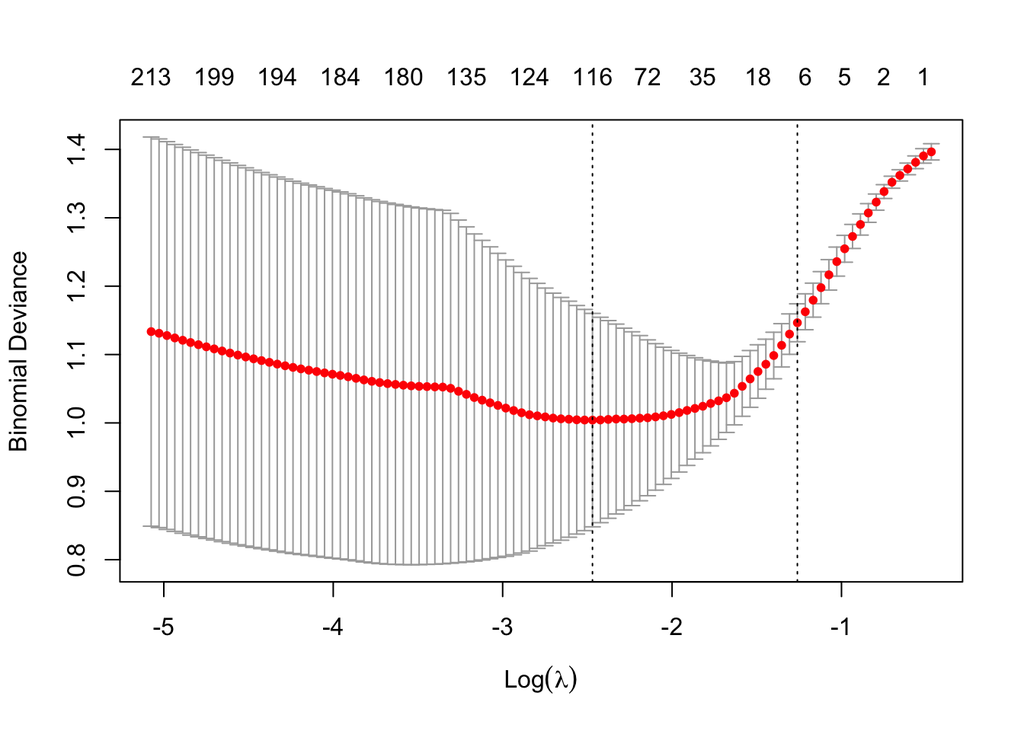

```r
set.seed(42L)
model <- cv.glmnet(X[train_id,], y[train_id], family = "binomial", alpha = 0.4)
plot(model)
```

Let’s look at the coefficients from the model selected by the elastic net function. The model puts a zero weight on most terms; we need only look at the terms that have a non-zero weight. We see that all of the selected terms have a negative sign (in other words, their presence is correlated with combination therapies). Also, most of these terms seem like reasonable indicators of a combination therapy.

```r
beta <- coef(model)
beta <- beta[apply(abs(beta), 1, sum) != 0,,drop=FALSE]
beta <- beta[c(1L, order(beta[-1]) + 1L),,drop=FALSE]
beta
```

```
## 9 x 1 sparse Matrix of class "dgCMatrix"
##                       s1
## (Intercept)  0.554885500
## plus        -0.263808294
## combination -0.109057953
## alone       -0.089242169
## +           -0.047557195
## and         -0.046236539
## /           -0.023633996
## intravenous -0.003784465
## quality     -0.003336507
```

Let’s evaluate how well the model performs. The overall accuracy rate is not bad (the data are balanced between monotherapy and combination therapies).

```r
pred <- predict(model, newx = X, type = "class")
tapply(y == pred, bladder_tomodel$bin, mean)
```

```
##     train     valid
## 0.8350515 0.7234043
```

```r
table(pred, y, bladder_tomodel$bin)
```

```
## , ,  = train
##
##              y
## pred          Combination Monotherapy
##   Combination          32           2
##   Monotherapy          14          49
##
## , ,  = valid
##
##              y
## pred          Combination Monotherapy
##   Combination          16           3
##   Monotherapy          10          18
```

Finally, a ROC curve shows that our model is fairly good at making predictions when the estimated probability is at one of the extreme values (corresponding to have none or many of the negative terms discovered above).

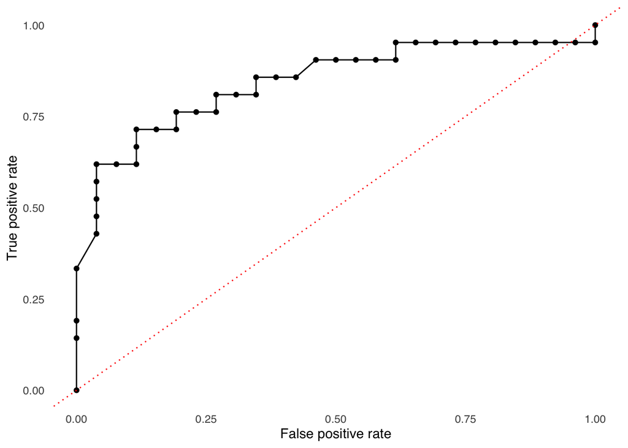

```r
pred_cont <- predict(
  model, newx = X[bladder_tomodel$bin == "valid",], type = "response"
)
pred_obj <- prediction(
  pred_cont, as.numeric(y[bladder_tomodel$bin == "valid"] == "Monotherapy")
)
perf <- performance(pred_obj, measure = "tpr", x.measure = "fpr")
tibble(fpr = perf@x.values[[1]], tpr = perf@y.values[[1]]) |>
  ggplot(aes(fpr, tpr)) +
    geom_point() +
    geom_line() +
    geom_abline(linetype = "dotted", color = "red") +
    labs(x = "False positive rate", y = "True positive rate")
```

As an alternative to the penalized estimation approach above, we can also try to build an expert system with hand-constructed rules to predict whether a trial is a monotherapy or combination therapy. The benefit of the expert rules is that we do not need to collapse all of the text fields into a single field and can instead build a model based on a complex combination of the different tables. The downside is that it is much more difficult for our hand-constructed expert rules to detect smaller, subtle patterns that may be predictive when aggregated.

Our general idea is to try to count the number of interventions present in the experimental arm of the trial. To start, we will look at the interventions table and filter to only include “real” interventions (biological, drugs, and radiation). Then, we’ll assume that each row is at a minimum an individual treatment; words such as “and”, “plus”, and “with” indicate a second treatment, as do common acronyms (MVAC and DVAC). We know that this will undercount the number of drugs when there are more than two, but since we only care about the difference between one treatement and more than one treatement, this will not effect the model.

```r
number_of_inters <- interventions |>
  filter(intervention_type %in% c("Biological", "Drug", "Radiation")) |>
  mutate(name = stri_trans_tolower(name)) |>
  mutate(num_inter = stri_detect(name, fixed = "with") +
                     stri_detect(name, fixed = "and") +
                     stri_detect(name, fixed = "+") +
                     stri_detect(name, fixed = "plus") +
                     stri_detect(name, fixed = "mvac") +
                     stri_detect(name, fixed = "dvac") +
                     1L) |>
  select(id, nct_id, num_inter)

number_of_inters
```

```
## # A tibble: 366 × 3
##          id nct_id      num_inter
##       <dbl> <chr>           <int>
##  1 19556452 NCT01387269         1
##  2 19556453 NCT01387269         1
##  3 19556454 NCT01387282         1
##  4 19556455 NCT01387282         1
##  5 19556799 NCT01395914         1
##  6 19556800 NCT01395914         1
##  7 19560570 NCT01515189         1
##  8 19563008 NCT01589094         2
##  9 19564854 NCT01605227         1
## 10 19564855 NCT01605227         1
## # … with 356 more rows
```

Now, we can join the interventions table to the design table to associate each intervention with an arm of the trial. We filter the experimental arm and then summarize to find the estimated number of treatements in each experimental group.

```r
number_of_inters_sum <- number_of_inters |>
  inner_join(
    select(design_gint, -id), by = c("id" = "intervention_id", "nct_id")
  ) |>
  inner_join(design_groups, by = c("design_group_id" = "id", "nct_id"),
             suffix = c("_intervention", "_design")) |>
  filter(group_type == "Experimental") |>
  group_by(nct_id, design_group_id) |>
  summarize(num_inter = sum(num_inter)) |>
  ungroup()

number_of_inters_sum
```

```
## # A tibble: 160 × 3
##    nct_id      design_group_id num_inter
##    <chr>                 <dbl>     <int>
##  1 NCT00003120        20742016         1
##  2 NCT00003644        20608969         2
##  3 NCT00011986        20610792         3
##  4 NCT00011986        20610793         3
##  5 NCT00011986        20610794         3
##  6 NCT00011986        20610795         3
##  7 NCT00033540        20610922         2
##  8 NCT00050960        20611171         3
##  9 NCT00050960        20611172         2
## 10 NCT00055601        20611259         4
## # … with 150 more rows
```

Now, we’ll combine the data from above with our hand-labeled data and categorize a treatement as Monotherapy if it has only a single intervention in the experimental arm and as a combination therapy otherwise.

```r
expert_rules <- number_of_inters_sum |>
  inner_join(select(bladder, nct_id, type_of_therapy, bin),  by = "nct_id") |>
  mutate(pred = if_else(num_inter == 1, "Monotherapy", "Combination"))

expert_rules
```

```
## # A tibble: 160 × 6
##    nct_id      design_group_id num_inter type_of_therapy bin   pred
##    <chr>                 <dbl>     <int> <chr>           <chr> <chr>
##  1 NCT00003120        20742016         1 Monotherapy     train Monotherapy
##  2 NCT00003644        20608969         2 Combination     valid Combination
##  3 NCT00011986        20610792         3 Combination     train Combination
##  4 NCT00011986        20610793         3 Combination     train Combination
##  5 NCT00011986        20610794         3 Combination     train Combination
##  6 NCT00011986        20610795         3 Combination     train Combination
##  7 NCT00033540        20610922         2 Combination     valid Combination
##  8 NCT00050960        20611171         3 Combination     valid Combination
##  9 NCT00050960        20611172         2 Combination     valid Combination
## 10 NCT00055601        20611259         4 Combination     train Combination
## # … with 150 more rows
```

Let’s see how well this works. In selecting the keywords above, we used on the training data. We’ll show the results by the train/validation split to be able to compare to the results above. Just based on accuracy, we see that the expert rules outperform the penalized regression approach:

```r
tapply(expert_rules$type_of_therapy == expert_rules$pred, expert_rules$bin, mean)
```

```
##     train     valid
## 0.9639640 0.9387755
```

We also see from a confusion matrix that there is not particular pattern to the mis-predicted labels.

```r
table(y = expert_rules$type_of_therapy, pred = expert_rules$pred, expert_rules$bin)
```

```
## , ,  = train
##
##              pred
## y             Combination Monotherapy
##   Combination          55           3
##   Monotherapy           1          52
##
## , ,  = valid
##
##              pred
## y             Combination Monotherapy
##   Combination          29           1
##   Monotherapy           2          17
```

As a final step, one can look at the mis-predicted trials and try to understand why our expert rules model made a mistake (a web search for the NCT ID will usually pull of the results on clinical trials website as the first hit).

```r
expert_rules |>
  filter(type_of_therapy != pred) |>
  arrange(type_of_therapy)
```

```
## # A tibble: 7 × 6
##   nct_id      design_group_id num_inter type_of_therapy bin   pred
##   <chr>                 <dbl>     <int> <chr>           <chr> <chr>
## 1 NCT00102804        20612371         1 Combination     train Monotherapy
## 2 NCT00312013        20762654         1 Combination     valid Monotherapy
## 3 NCT01085136        20653334         1 Combination     train Monotherapy
## 4 NCT02111577        20691855         1 Combination     train Monotherapy
## 5 NCT01721772        20716505         2 Monotherapy     valid Combination
## 6 NCT02042443        20689839         3 Monotherapy     train Combination
## 7 NCT02106546        20414120         3 Monotherapy     valid Combination
```